# Análisis de Datos Panel: Determinantes del PIB per cápita

Derek Martell - Mundo Social

2025-06-03

# Introducción

```r
library(plm)      # Modelos de datos panel
library(readxl)   # Para lectura de archivos Excel (no usado aquí, pero puede ser útil)
```

# Importación de datos

```r
# Ruta del archivo CSV
path <- "C:/eco-poli/TRABAJO FINAL/CÓDIGO EN R/merged_df_sin_ecuador.csv"
df <- read.csv(path)
```

# Conversión a estructura panel

```r
df <- pdata.frame(df, index = c("Country", "Index.Year"))
```

- Se especifica que los datos están organizados por país y año.

# Análisis exploratorio

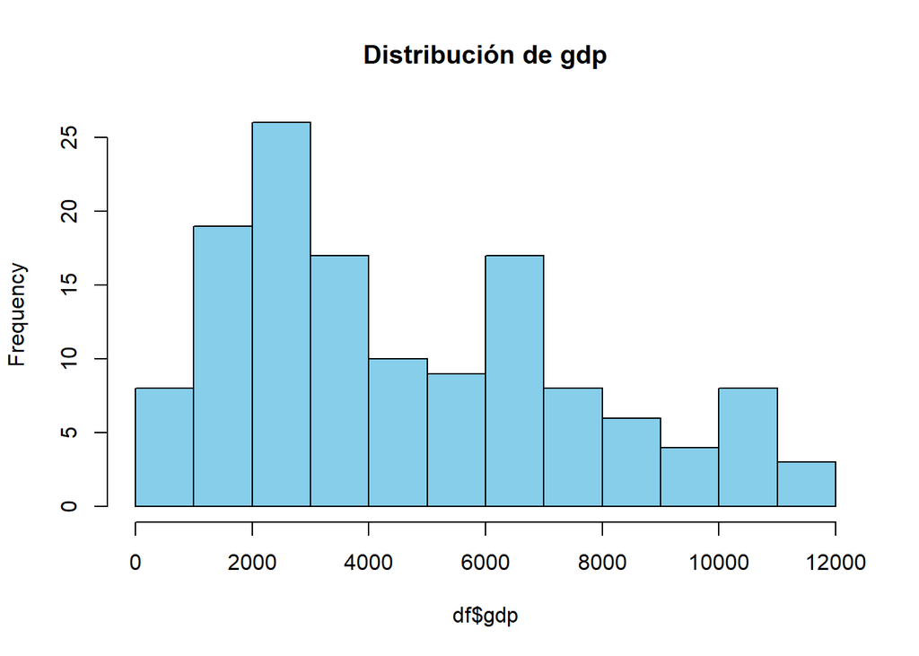

```r
hist(df$gdp, main = "Distribución de gdp", col = "skyblue")
```

- El histograma muestra la distribución del PIB per cápita. Suele ser sesgada, por lo que aplicamos una transformación logarítmica.

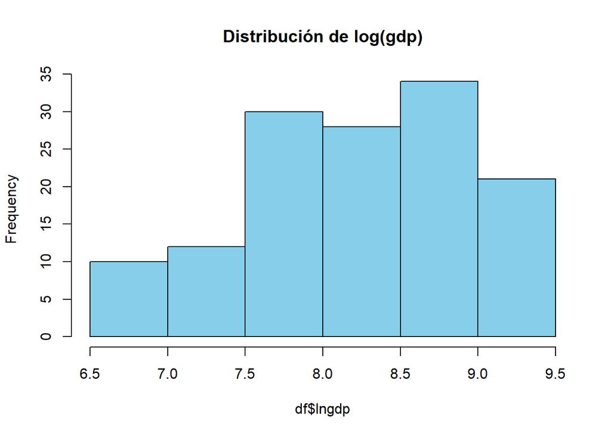

```r
df$lngdp <- log(df$gdp)
hist(df$lngdp, main = "Distribución de log(gdp)", col = "skyblue")
```

- El logaritmo ayuda a normalizar la distribución.

# Correlación entre variables explicativas

```r
cor(df[, c("capi", "art", "labor", "Overall.Score")])
```

```
##                    capi       art     labor Overall.Score
## capi          1.0000000 0.4480974 0.5426616     0.2566290
## art           0.4480974 1.0000000 0.9134098     0.2962500
## labor         0.5426616 0.9134098 1.0000000     0.3391569
## Overall.Score 0.2566290 0.2962500 0.3391569     1.0000000
```

- Se evalúa multicolinealidad. Correlaciones altas podrían afectar la estimación.

# Modelo Pooled (OLS)

```r
reg_pool <- plm(gdp ~ capi + art + labor + Overall.Score, data = df, model = "pooling")
summary(reg_pool)
```

```
## Pooling Model
##
## Call:
## plm(formula = gdp ~ capi + art + labor + Overall.Score, data = df,
##     model = "pooling")
##
## Balanced Panel: n = 5, T = 27, N = 135
##
## Residuals:
##     Min.  1st Qu.   Median  3rd Qu.     Max.
## -2347.26  -978.62  -233.51  1004.30  2717.76
##
## Coefficients:
##                  Estimate  Std. Error t-value  Pr(>|t|)
## (Intercept)   -1.6289e+03  1.2655e+03 -1.2872   0.20032
## capi           1.6641e+02  4.1261e+01  4.0331 9.329e-05 ***
## art            1.1865e-01  5.3076e-02  2.2356   0.02709 *
## labor          1.0876e-04  1.8415e-05  5.9062 2.883e-08 ***
## Overall.Score  1.0890e+01  1.8363e+01  0.5930   0.55419
## ---
## Signif. codes:  0 '***' 0.001 '**' 0.01 '*' 0.05 '.' 0.1 ' ' 1
##
## Total Sum of Squares:    1151300000
## Residual Sum of Squares: 210880000
## R-Squared:      0.81684
## Adj. R-Squared: 0.8112
## F-statistic: 144.94 on 4 and 130 DF, p-value: < 2.22e-16
```

- Asume que no hay efectos no observados entre países o años.
- Los coeficientes muestran el impacto marginal de cada variable sobre el PIB per cápita.
- No controla por heterogeneidad no observada.

# Modelo de Efectos Fijos

```r
reg_fe <- plm(gdp ~ capi + art + labor + Overall.Score, data = df, model = "within")
summary(reg_fe)
```

```
## Oneway (individual) effect Within Model
##
## Call:
## plm(formula = gdp ~ capi + art + labor + Overall.Score, data = df,
##     model = "within")
##
## Balanced Panel: n = 5, T = 27, N = 135
##
## Residuals:
##      Min.   1st Qu.    Median   3rd Qu.      Max.
## -2616.635  -751.704    38.595   588.061  2327.835
##
## Coefficients:
##                  Estimate  Std. Error t-value  Pr(>|t|)
## capi           1.3634e+02  3.6948e+01  3.6902 0.0003321 ***
## art           -4.1058e-01  7.7717e-02 -5.2830 5.408e-07 ***
## labor          6.1517e-04  6.1207e-05 10.0507 < 2.2e-16 ***
## Overall.Score  1.7422e+00  1.8805e+01  0.0926 0.9263303
## ---
## Signif. codes:  0 '***' 0.001 '**' 0.01 '*' 0.05 '.' 0.1 ' ' 1
##
## Total Sum of Squares:    379790000
## Residual Sum of Squares: 122820000
## R-Squared:      0.6766
## Adj. R-Squared: 0.65606
## F-statistic: 65.9019 on 4 and 126 DF, p-value: < 2.22e-16
```

- Controla por factores no observables que son constantes en el tiempo dentro de cada país.
- Ideal si creemos que existen características no medidas (como instituciones o cultura) que afectan al PIB.
- Se enfoca en las variaciones dentro de cada país.

# Modelo de Efectos Aleatorios

```r
reg_re <- plm(gdp ~ capi + art + labor + Overall.Score,
              data = df,
              model = "random",
              random.method = "amemiya")
summary(reg_re)
```

```
## Oneway (individual) effect Random Effect Model
##    (Amemiya's transformation)
##
## Call:
## plm(formula = gdp ~ capi + art + labor + Overall.Score, data = df,
##     model = "random", random.method = "amemiya")
##
## Balanced Panel: n = 5, T = 27, N = 135
##
## Effects:
##                    var  std.dev share
## idiosyncratic   944806      972 0.029
## individual    31874785     5646 0.971
## theta: 0.9669
##
## Residuals:
##      Min.   1st Qu.    Median   3rd Qu.      Max.
## -2859.814  -720.028    49.053   668.627  2321.872
##
## Coefficients:
##                  Estimate  Std. Error z-value  Pr(>|z|)
## (Intercept)   -7.6962e+03  3.0561e+03 -2.5183 0.0117921 *
## capi           1.3909e+02  3.6995e+01  3.7597 0.0001702 ***
## art           -3.7661e-01  7.6213e-02 -4.9416  7.75e-07 ***
## labor          5.8364e-04  5.9511e-05  9.8072 < 2.2e-16 ***
## Overall.Score  4.0594e-01  1.8825e+01  0.0216 0.9827953
## ---
## Signif. codes:  0 '***' 0.001 '**' 0.01 '*' 0.05 '.' 0.1 ' ' 1
##
## Total Sum of Squares:    380640000
## Residual Sum of Squares: 127260000
## R-Squared:      0.66566
## Adj. R-Squared: 0.65537
## Chisq: 258.824 on 4 DF, p-value: < 2.22e-16
```

- Supone que las diferencias no observadas entre países no están correlacionadas con las variables explicativas.
- Más eficiente que FE si los supuestos se cumplen.

# Comparación de modelos

## Test F: ¿Pooled vs. Efectos Fijos?

```r
pFtest(reg_fe, reg_pool)
```

```
##
##  F test for individual effects
##
## data:  gdp ~ capi + art + labor + Overall.Score
## F = 22.582, df1 = 4, df2 = 126, p-value = 4.44e-14
## alternative hypothesis: significant effects
```

- H₀: El modelo Pooled es adecuado (sin efectos individuales).
- H₁: El modelo de Efectos Fijos es preferido.
- Si el valor p es bajo (p < 0.05), se rechaza H₀ ⇒ se prefiere Efectos Fijos.

## Test de Hausman: ¿Efectos Aleatorios vs. Efectos Fijos?

```r
phtest(reg_re, reg_fe)
```

```
##
##  Hausman Test
##
## data:  gdp ~ capi + art + labor + Overall.Score
## chisq = 4.8406, df = 4, p-value = 0.304
## alternative hypothesis: one model is inconsistent
```

- H₀: El modelo de Efectos Aleatorios es consistente.
- H₁: El modelo de Efectos Fijos es preferido.
- Si el valor p es bajo ⇒ hay correlación entre efectos no observados y las variables ⇒ usar FE.

# Conclusión

- Si ambos tests favorecen el modelo de Efectos Fijos, se concluye que existen efectos específicos de país que deben ser controlados.
- Si el Test de Hausman no rechaza H₀, Efectos Aleatorios es más eficiente.
- La elección final del modelo depende del resultado de las pruebas y del objetivo del análisis.